# Unsupervised ML by Andrew Ng

Hana Le

2023-03-30

### Learning Unsupervised ML with Andrew Ng: My Experience

I recently had the opportunity to take [Andrew Ng’s Unsupervised Machine Learning course on Coursera](https://www.coursera.org/learn/machine-learning?specialization=machine-learning-introduction). This course is part of the Machine Learning specialization program created by Stanford University in partnership with Deeplearning.Ai. I was interested to learn more about machine learning and, in particular, develop my Python skills. I have to say, the course was really worth it.

The course starts with the basics, covering linear regression, logistic regression, and gradient descent for model training. It’s well-structured, easy to follow, and Andrew’s presentation style is fantastic. He uses lots of visual aids to explain concepts, which is helpful if you’re not confident with math or statistics. However, some prior knowledge of basic math and stats is required, especially when it comes to more advanced machine learning topics.

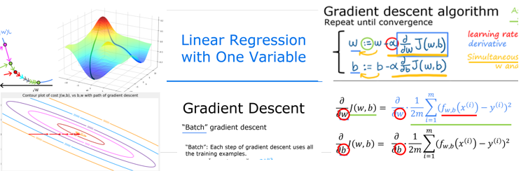

One of the highlights about this course is the interactive graphs Andrew uses to explain the concepts. The exercises and assignments are in Python using Jupyter notebooks, which are challenging but not overwhelming.

The course takes about 3 weeks if you study for 9-10 hours per week, but if you’re familiar with some of the topics, you may be able to complete it more quickly. I personally managed to finish it in less than a week, as I had some prior knowledge from a similar course, I took in school a while ago. Nonetheless, I still found the course to be incredibly useful in consolidating my knowledge of machine learning and improving my Python skills.

I would highly recommend this course as a great introduction to unsupervised machine learning. It’s an excellent first step in the Machine Learning specialization program, which I’m planning to continue with by taking the other two courses. I’m excited to see where this learning journey takes me and what new opportunities it may open up for me.